# Poverty vs. Education Report

Liam Lindhe-Johan, Maryory Ajpop, Anand Puri, Beem Chivatxaranukul

2023-12-08

# Introduction

In researching a topic for this project the group decided they wanted to focus not on something that could be arbitrarily related, but a subject we knew must in some way be correlated. We wanted to tackle an issue that many are aware of, but often overlook due to how abstract of a concept it can be. The group decided on the level of education versus the amount of poverty in a location in the United States because we wanted a better understanding of where and how divisions in the educational field began to arise. This subject is crucially important for the future of both education and economics in the United States as the relationship between these variables can have impacts that span generations.

We already know that at a baseline there is a correlation between income and education. This is due to several widely known and understood factors such as segregation, redlining, discrimination, and so on. The group already knew about these factors before deciding on our final data sets, and that was part of the reason we all felt it important to do our project on this subject in particular. While we all understood that this problem existed, none of us knew where it was worst or to what extent it is still prevalent, and we felt that if we had these questions, others would likely do as well.

The questions that our group posed to focus our research and our project design process were:

In answering these questions we wanted to further understand the extent to which education affects the poverty of a location and if a more educated population truly leads to a lower rate of poverty.

This topic is incredibly important for the future of the United States and is intrinsically tied to almost every person’s life to some extent. Recognizing how prominent and impactful these factors are in the overall poverty of the USA is a crucial step in the improvement of these issues, no matter what educational or economic background you originate from. These issues have affected all of us either directly or indirectly throughout the course of our lives and for us as a country to begin healing some of this damage we must first understand how and where it exists. This report will attempt to shine a light on the places in which the problems of education and poverty plague our country the most, and we as a group will seek to educate ourselves and others on the importance of these issues.

# Data

The data sets we used were:

```
## # A tibble: 3,155 × 6
##    FIPS_Code State Area.name       Percent.of.adults.wi…¹ Percent.of.adults.co…²
##        <int> <chr> <chr>                            <dbl>                  <dbl>
##  1      1001 AL    Autauga County                    32.8                   28.7
##  2      1003 AL    Baldwin County                    27.4                   31.2
##  3      1005 AL    Barbour County                    36.7                   27.8
##  4      1007 AL    Bibb County                       43.9                   24.7
##  5      1009 AL    Blount County                     35.1                   33.6
##  6      1011 AL    Bullock County                    41.3                   24.6
##  7      1013 AL    Butler County                     45.2                   26.3
##  8      1015 AL    Calhoun County                    34.6                   31.1
##  9      1017 AL    Chambers County                   36.2                   32.9
## 10      1019 AL    Cherokee County                   36.9                   30.1
## # ℹ 3,145 more rows
## # ℹ abbreviated names:
## #   ¹Percent.of.adults.with.a.high.school.diploma.only..2017.21,
## #   ²Percent.of.adults.completing.some.college.or.associate.s.degree..2017.21
## # ℹ 1 more variable:
## #   Percent.of.adults.with.a.bachelor.s.degree.or.higher..2017.21 <dbl>
```

```
## # A tibble: 3,144 × 2
##    FIPS_Code PCTPOVALL_2021
##        <int>          <dbl>
##  1      1001           10.7
##  2      1003           10.8
##  3      1005           23
##  4      1007           20.6
##  5      1009           12
##  6      1011           32.1
##  7      1013           22.7
##  8      1015           19.2
##  9      1017           19.7
## 10      1019           18.2
## # ℹ 3,134 more rows
```

While they don’t show up well unformatted in R, they functioned well for our purposes as they aligned with each other quite nicely and gave us more than the amount of information we were initially looking for.

Both of our data sets came from the Economic Research Service which is a part of the federal government with the goal of documenting important statistics such as these.

As this is a public and freely accessible arm of the federal government, anyone with an internet connection and the means to store the files can access both of these data sets. The data does not have any specific restrictions on it and is free to be used by anyone for essentially any purpose.

The data sets are fairly broad with entries on multiple facets of both education and poverty in all of the available counties in each state of the United States. The population of the data sets were clearly the residents of the USA and their education amount and poverty level. The sample for both of these data sets is the responses they received from their online surveys and the contents of the immense library of past survey responses from the rest of the government.

There were a few minor issues with the data such as formatting and misleading column labels, these are fairly visible from the earlier visualizations. Before we could begin using the data we had to overhaul the categorization and formatting system both data sets originally had. The worst of the two issues was absolutely the column titles, especially in the poverty data set in which they are entirely unviewable without a secondary cheat sheet defining each column individually.

#Methods

We analyzed data collected by the US Government regarding poverty and education in the United States. There were a lot of variables to choose from, but we wanted a general overview of the correlation between poverty and education levels at a county level. From the poverty dataset, all we needed was the percentage of people in the county, as well as the FIPS code (Federal Information Processing Standard) to define each county. From the education dataset, we took a couple different variables - percentage of people in the county that have only a high school diploma, percentage of people that have some college experience and/or an associates, and percentage of people that have a bachelor’s degree or higher. These allowed us to compute differences in counties with differing levels of education.

To process our data, we first deleted unnecessary data that we would not use. Additionally, the education dataset had some text in the first cell that messed up the CSV file and by extension our attempts to parse through it, so we deleted that as well. Then we loaded both datasets into an R-Markdown file, renamed both FIPS code columns to be the same, and then used the merge function to merge them by the FIPS code column. This gave us a joint dataset that had information from both the education and poverty datasets. From here, we added a variable that represents the amount of people in each county that have a high school diploma or less, as the previous variable did not account for those without a high school diploma.

We had a significant amount of data, but it wasn’t enough to keep us from using every single county as a part of the sample. We did not have to reduce our data points to have a reasonable time complexity.

For our last visualization, we wanted to figure out what part of the population was both in poverty and had each specific education level. To do that, we took each of the education level variables (highschool and lower, associates/some college, bachelor’s or higher) and multiplied them by the poverty percentage in each county. We then found the mean of each of the newly created variables, and put them on a bar graph. Secondly, for each of our scatterplots, we added a trend line using linear regression.

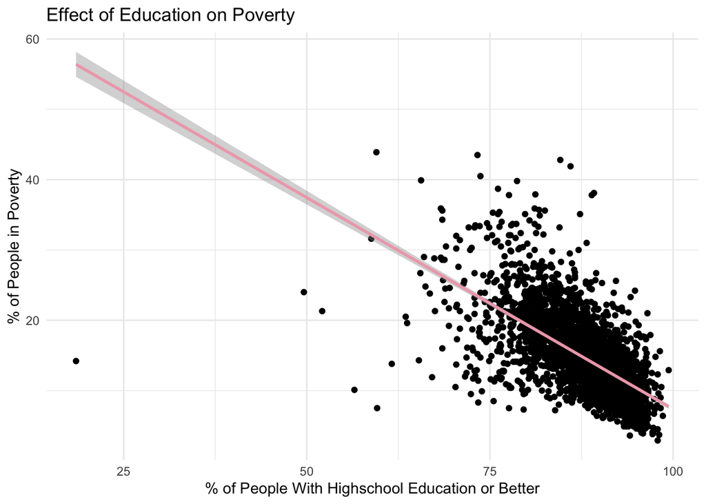

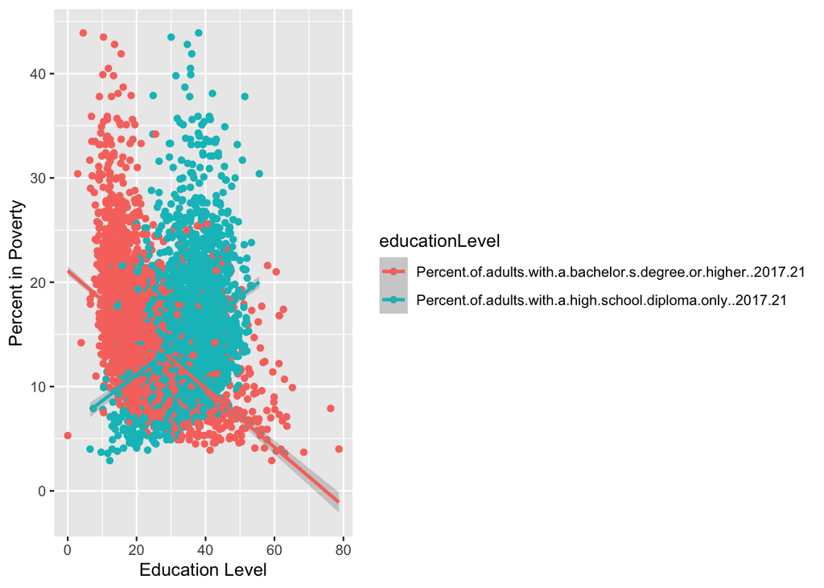

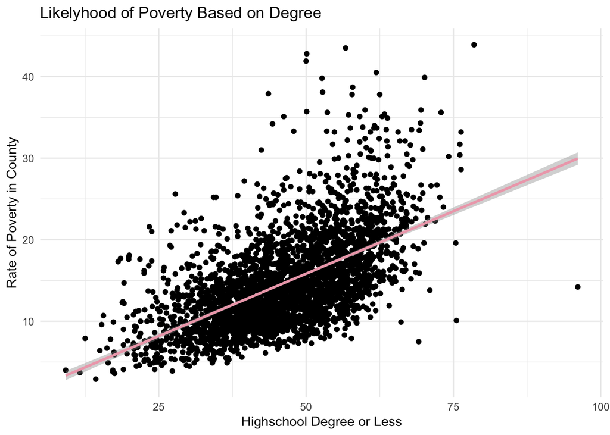

In our examination of the line graphs, a correlation emerged for individuals with a high school degree or lower which actually indicated a direct relationship between lower educational attainment and higher poverty rates. On the other hand, those with a college degree or higher exhibited an inverse relationship, showing decreasing poverty rates as the population of those with college degrees increased.

```
## [1] 0.07078217
```

```
## [1] 0.04446653
```

```
## [1] 0.03085693
```

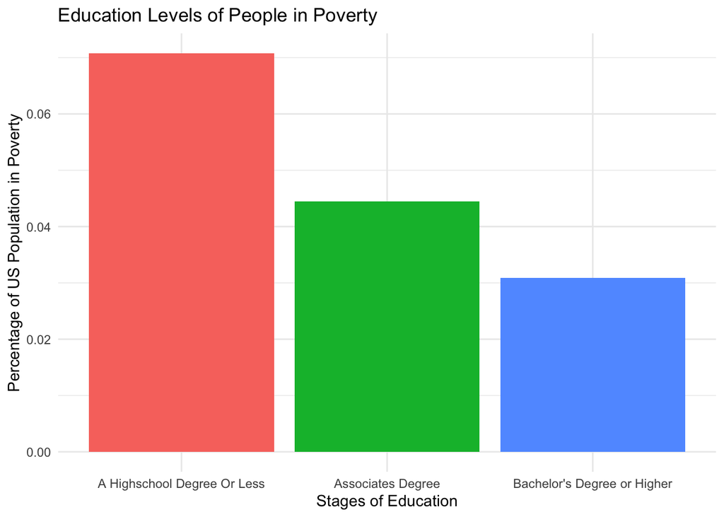

# Findings

The results we gathered illustrate the relationship between education levels and poverty rates in the United States. The various visualizations offer valuable insights into how access to education could influence an individual’s economic well-being.

In the line graphs, there is a clear correlation between lower educational levels and higher poverty rates, especially for individuals with a high school degree or less. Contrarily, those with a college degree or higher show an inverse relationship, demonstrating that higher education is associated with lower poverty rates. This finding reveals the importance of education for economic prosperity.

On the bar graph, a significant portion of the population in poverty is composed of individuals with a high school education or less, accounting for around 7% of the overall poverty rate. This reinforces the idea that addressing educational disparities, particularly at the high school level, could have a notable impact on reducing poverty rates.

The data sets, while vast, may not capture all the fine details of the complex relationship between education and poverty as the study focuses on correlations, not causation, leaving room for other factors influencing poverty rates.

As for future work, this could involve a deeper exploration of specific demographic factors within educational levels. Analyzing additional variables such as race and gender could provide a more profound understanding of the disparities.

While our findings offer valuable insights into the relationship between education and poverty, there is great potential for more in-depth analyses and exploration of additional variables to refine our understanding of this highly complex and critical issue.

# Summary

During our work on this project, the group gained an important understanding of the true impact of the data we were studying. As we analyzed and processed our data sets the power of what we were creating became increasingly more evident. The relationships between these variables display a multitude of shortcomings within our country and an understanding of them is absolutely necessary if we do hope to solve these issues. Knowing what we know now about the direct impact education has on the poverty of an area we can look to further research on how and why these relationships exist in the first place. While the topic we chose is a fairly well-known relationship, many citizens of the United States are unaware of just how proportional these two variables are to each other. With the creation of our visualizations, we wanted to demonstrate a clear understanding of the data that could reach and be understood by as many as possible. With our project, we hoped to decrease barriers to data and create a framework for a future without this glaring problem in the United States.